# GROUP-05-HCDR

## Team and project meta information

### Members:

- Athulya Anand - 2000923101 - athanand@iu.edu
- Shubham Patil - 2000938033 - shupatil@iu.edu
- Sricharraan Ramaswamy - 2000855651 - sriramas@iu.edu
- Varsha R - 2000751388 - varavi@iu.edu

[figure not shown]

## Project Abstract

The course project is based on the [Home Credit Default Risk (HCDR) Kaggle Competition](https://www.kaggle.com/c/home-credit-default-risk/).

To be able to perform the prediction, machine learning algorithms play an important role in achieving the desired results. To achieve the best accuracy, we have selected the following three algorithms from which we compare and derive the best results.

- **Naive Bayes:** Naive Bayes is based on Bayes's Theorem and the assumption of independence between predictors. This algorithm is particularly useful with such a large dataset because the model is easy to build, with no complicated iterative parameter estimation.
- **Logistic Regression:** Logistic regression predicts the likelihood of a dichotomous outcome. It is based on using one or more predictors. This method produces a logistic curve whose range is limited to values between 0 and 1.
- **Random Forest:** This model can be used for both classification and regression. Put the input vector down each tree in the forest in order to classify a new object from the input vector. Ultimately, it is the classification with the greatest number of votes that is selected. The accuracy of the method will be compared with that of logistic regression in the test case

To summarize, the challenge is to construct a model that can predict the level of risk associated with an individual loan. With this project, we intend to use historical loan application data to predict whether or not a borrower will be able to repay a loan. In short, the goal of this project is to predict whether or not a client will repay a loan.

## Project Description (tasks and data)

### Tasks

Importing all the necessary python libraries:

```python
import pandas as pd
import seaborn as sb
import matplotlib.pyplot as plt
```

### Data

Dataset link: https://www.kaggle.com/c/home-credit-default-risk/data

#### Background of the data

Home Credit is a non-banking financial institution, founded in 1997 in the Czech Republic.

The company operates in 14 countries (including United States, Russia, Kazahstan, Belarus, China, India) and focuses on lending primarily to people with little or no credit history which will either not obtain loans or became victims of untrustworthly lenders.

Home Credit group has over 29 million customers, total assests of 21 billions Euro, over 160 millions loans, with the majority in Asia and and almost half of them in China (as of 19-05-2018).

While Home Credit is currently using various statistical and machine learning methods to make these predictions, they're challenging Kagglers to help them unlock the full potential of their data. Doing so will ensure that clients capable of repayment are not rejected and that loans are given with a principal, maturity, and repayment calendar that will empower their clients to be successful.

#### Data files overview

There are 7 different sources of data:

- **application_train/application_test:** the main training and testing data with information about each loan application at Home Credit. Every loan has its own row and is identified by the feature SK_ID_CURR. The training application data comes with the TARGET indicating **0: the loan was repaid** or **1: the loan was not repaid**. The target variable defines if the client had payment difficulties meaning he/she had late payment more than X days on at least one of the first Y installments of the loan. Such case is marked as 1 while other all other cases as 0.
- **bureau:** data concerning client's previous credits from other financial institutions. Each previous credit has its own row in bureau, but one loan in the application data can have multiple previous credits.
- **bureau_balance:** monthly data about the previous credits in bureau. Each row is one month of a previous credit, and a single previous credit can have multiple rows, one for each month of the credit length.
- **previous_application:** previous applications for loans at Home Credit of clients who have loans in the application data. Each current loan in the application data can have multiple previous loans. Each previous application has one row and is identified by the feature SK_ID_PREV.
- **POS_CASH_BALANCE:** monthly data about previous point of sale or cash loans clients have had with Home Credit. Each row is one month of a previous point of sale or cash loan, and a single previous loan can have many rows.
- credit_card_balance: monthly data about previous credit cards clients have had with Home Credit. Each row is one month of a credit card balance, and a single credit card can have many rows.
- **installments_payment:** payment history for previous loans at Home Credit. There is one row for every made payment and one row for every missed payment.

[figure not shown]

Reading the csv data files:

```python
df_train = pd.read_csv('application_train.csv')
df_test = pd.read_csv('application_test.csv')
```

## Exploratory Data Analysis

EDA, or exploratory data analysis, is an essential component of any Data Analysis or Data Science project. Essentially, EDA entails analyzing the dataset to identify patterns, anomalies (outliers), and hypotheses based on our understanding of the dataset.

EDA is primarily used to see what data can reveal beyond the formal modeling or hypothesis testing task and provides a provides a better understanding of data set variables and the relationships between them. It can also help determine if the statistical techniques you are considering for data analysis are appropriate.

### Data description using pandas dataframe

Pandas DataFrame is two-dimensional size-mutable, potentially heterogeneous tabular data structure with labeled axes (rows and columns). A Data frame is a two-dimensional data structure, i.e., data is aligned in a tabular fashion in rows and columns. Pandas DataFrame consists of three principal components, the data, rows, and columns.

- **head():** This function returns the first n rows for the object based on position. It is useful for quickly testing if your object has the right type of data in it. For negative values of n, this function returns all rows except the last n rows, equivalent to df[:-n].
- **describe():** Descriptive statistics include those that summarize the central tendency, dispersion and shape of a dataset’s distribution, excluding NaN values.
- **info():** Pandas dataframe.info() function is used to get a concise summary of the dataframe. It comes really handy when doing exploratory analysis of the data. To get a quick overview of the dataset we use the dataframe.info() function.

#### Training data information

```python
print ("\nhead():\n")
df_train.head()
```

```
head():
```

|  | SK_ID_CURR | TARGET | NAME_CONTRACT_TYPE | CODE_GENDER | FLAG_OWN_CAR | FLAG_OWN_REALTY | CNT_CHILDREN | AMT_INCOME_TOTAL | AMT_CREDIT | AMT_ANNUITY | ... | FLAG_DOCUMENT_18 | FLAG_DOCUMENT_19 | FLAG_DOCUMENT_20 | FLAG_DOCUMENT_21 | AMT_REQ_CREDIT_BUREAU_HOUR | AMT_REQ_CREDIT_BUREAU_DAY | AMT_REQ_CREDIT_BUREAU_WEEK | AMT_REQ_CREDIT_BUREAU_MON | AMT_REQ_CREDIT_BUREAU_QRT | AMT_REQ_CREDIT_BUREAU_YEAR |
| --- | --- | --- | --- | --- | --- | --- | --- | --- | --- | --- | --- | --- | --- | --- | --- | --- | --- | --- | --- | --- | --- |
| 0 | 100002 | 1 | Cash loans | M | N | Y | 0 | 202500.0 | 406597.5 | 24700.5 | ... | 0 | 0 | 0 | 0 | 0.0 | 0.0 | 0.0 | 0.0 | 0.0 | 1.0 |
| 1 | 100003 | 0 | Cash loans | F | N | N | 0 | 270000.0 | 1293502.5 | 35698.5 | ... | 0 | 0 | 0 | 0 | 0.0 | 0.0 | 0.0 | 0.0 | 0.0 | 0.0 |
| 2 | 100004 | 0 | Revolving loans | M | Y | Y | 0 | 67500.0 | 135000.0 | 6750.0 | ... | 0 | 0 | 0 | 0 | 0.0 | 0.0 | 0.0 | 0.0 | 0.0 | 0.0 |
| 3 | 100006 | 0 | Cash loans | F | N | Y | 0 | 135000.0 | 312682.5 | 29686.5 | ... | 0 | 0 | 0 | 0 | NaN | NaN | NaN | NaN | NaN | NaN |
| 4 | 100007 | 0 | Cash loans | M | N | Y | 0 | 121500.0 | 513000.0 | 21865.5 | ... | 0 | 0 | 0 | 0 | 0.0 | 0.0 | 0.0 | 0.0 | 0.0 | 0.0 |

5 rows × 122 columns

```python
print ("\ndescribe():\n")
df_train.describe()
```

```
describe():
```

|  | SK_ID_CURR | TARGET | CNT_CHILDREN | AMT_INCOME_TOTAL | AMT_CREDIT | AMT_ANNUITY | AMT_GOODS_PRICE | REGION_POPULATION_RELATIVE | DAYS_BIRTH | DAYS_EMPLOYED | ... | FLAG_DOCUMENT_18 | FLAG_DOCUMENT_19 | FLAG_DOCUMENT_20 | FLAG_DOCUMENT_21 | AMT_REQ_CREDIT_BUREAU_HOUR | AMT_REQ_CREDIT_BUREAU_DAY | AMT_REQ_CREDIT_BUREAU_WEEK | AMT_REQ_CREDIT_BUREAU_MON | AMT_REQ_CREDIT_BUREAU_QRT | AMT_REQ_CREDIT_BUREAU_YEAR |
| --- | --- | --- | --- | --- | --- | --- | --- | --- | --- | --- | --- | --- | --- | --- | --- | --- | --- | --- | --- | --- | --- |
| count | 307511.000000 | 307511.000000 | 307511.000000 | 3.075110e+05 | 3.075110e+05 | 307499.000000 | 3.072330e+05 | 307511.000000 | 307511.000000 | 307511.000000 | ... | 307511.000000 | 307511.000000 | 307511.000000 | 307511.000000 | 265992.000000 | 265992.000000 | 265992.000000 | 265992.000000 | 265992.000000 | 265992.000000 |
| mean | 278180.518577 | 0.080729 | 0.417052 | 1.687979e+05 | 5.990260e+05 | 27108.573909 | 5.383962e+05 | 0.020868 | -16036.995067 | 63815.045904 | ... | 0.008130 | 0.000595 | 0.000507 | 0.000335 | 0.006402 | 0.007000 | 0.034362 | 0.267395 | 0.265474 | 1.899974 |
| std | 102790.175348 | 0.272419 | 0.722121 | 2.371231e+05 | 4.024908e+05 | 14493.737315 | 3.694465e+05 | 0.013831 | 4363.988632 | 141275.766519 | ... | 0.089798 | 0.024387 | 0.022518 | 0.018299 | 0.083849 | 0.110757 | 0.204685 | 0.916002 | 0.794056 | 1.869295 |
| min | 100002.000000 | 0.000000 | 0.000000 | 2.565000e+04 | 4.500000e+04 | 1615.500000 | 4.050000e+04 | 0.000290 | -25229.000000 | -17912.000000 | ... | 0.000000 | 0.000000 | 0.000000 | 0.000000 | 0.000000 | 0.000000 | 0.000000 | 0.000000 | 0.000000 | 0.000000 |
| 25% | 189145.500000 | 0.000000 | 0.000000 | 1.125000e+05 | 2.700000e+05 | 16524.000000 | 2.385000e+05 | 0.010006 | -19682.000000 | -2760.000000 | ... | 0.000000 | 0.000000 | 0.000000 | 0.000000 | 0.000000 | 0.000000 | 0.000000 | 0.000000 | 0.000000 | 0.000000 |
| 50% | 278202.000000 | 0.000000 | 0.000000 | 1.471500e+05 | 5.135310e+05 | 24903.000000 | 4.500000e+05 | 0.018850 | -15750.000000 | -1213.000000 | ... | 0.000000 | 0.000000 | 0.000000 | 0.000000 | 0.000000 | 0.000000 | 0.000000 | 0.000000 | 0.000000 | 1.000000 |
| 75% | 367142.500000 | 0.000000 | 1.000000 | 2.025000e+05 | 8.086500e+05 | 34596.000000 | 6.795000e+05 | 0.028663 | -12413.000000 | -289.000000 | ... | 0.000000 | 0.000000 | 0.000000 | 0.000000 | 0.000000 | 0.000000 | 0.000000 | 0.000000 | 0.000000 | 3.000000 |
| max | 456255.000000 | 1.000000 | 19.000000 | 1.170000e+08 | 4.050000e+06 | 258025.500000 | 4.050000e+06 | 0.072508 | -7489.000000 | 365243.000000 | ... | 1.000000 | 1.000000 | 1.000000 | 1.000000 | 4.000000 | 9.000000 | 8.000000 | 27.000000 | 261.000000 | 25.000000 |

8 rows × 106 columns

```python
print ("\ninfo():\n")
df_train.info()
```

```
info():

<class 'pandas.core.frame.DataFrame'>
RangeIndex: 307511 entries, 0 to 307510
Columns: 122 entries, SK_ID_CURR to AMT_REQ_CREDIT_BUREAU_YEAR
dtypes: float64(65), int64(41), object(16)
memory usage: 286.2+ MB
```

#### Testing data information

```python
print ("\nhead():\n")
df_test.head()
```

```
head():
```

|  | SK_ID_CURR | NAME_CONTRACT_TYPE | CODE_GENDER | FLAG_OWN_CAR | FLAG_OWN_REALTY | CNT_CHILDREN | AMT_INCOME_TOTAL | AMT_CREDIT | AMT_ANNUITY | AMT_GOODS_PRICE | ... | FLAG_DOCUMENT_18 | FLAG_DOCUMENT_19 | FLAG_DOCUMENT_20 | FLAG_DOCUMENT_21 | AMT_REQ_CREDIT_BUREAU_HOUR | AMT_REQ_CREDIT_BUREAU_DAY | AMT_REQ_CREDIT_BUREAU_WEEK | AMT_REQ_CREDIT_BUREAU_MON | AMT_REQ_CREDIT_BUREAU_QRT | AMT_REQ_CREDIT_BUREAU_YEAR |
| --- | --- | --- | --- | --- | --- | --- | --- | --- | --- | --- | --- | --- | --- | --- | --- | --- | --- | --- | --- | --- | --- |
| 0 | 100001 | Cash loans | F | N | Y | 0 | 135000.0 | 568800.0 | 20560.5 | 450000.0 | ... | 0 | 0 | 0 | 0 | 0.0 | 0.0 | 0.0 | 0.0 | 0.0 | 0.0 |
| 1 | 100005 | Cash loans | M | N | Y | 0 | 99000.0 | 222768.0 | 17370.0 | 180000.0 | ... | 0 | 0 | 0 | 0 | 0.0 | 0.0 | 0.0 | 0.0 | 0.0 | 3.0 |
| 2 | 100013 | Cash loans | M | Y | Y | 0 | 202500.0 | 663264.0 | 69777.0 | 630000.0 | ... | 0 | 0 | 0 | 0 | 0.0 | 0.0 | 0.0 | 0.0 | 1.0 | 4.0 |
| 3 | 100028 | Cash loans | F | N | Y | 2 | 315000.0 | 1575000.0 | 49018.5 | 1575000.0 | ... | 0 | 0 | 0 | 0 | 0.0 | 0.0 | 0.0 | 0.0 | 0.0 | 3.0 |
| 4 | 100038 | Cash loans | M | Y | N | 1 | 180000.0 | 625500.0 | 32067.0 | 625500.0 | ... | 0 | 0 | 0 | 0 | NaN | NaN | NaN | NaN | NaN | NaN |

5 rows × 121 columns

```python
print ("\ndescribe():\n")
df_test.describe()
```

```
describe():
```

|  | SK_ID_CURR | CNT_CHILDREN | AMT_INCOME_TOTAL | AMT_CREDIT | AMT_ANNUITY | AMT_GOODS_PRICE | REGION_POPULATION_RELATIVE | DAYS_BIRTH | DAYS_EMPLOYED | DAYS_REGISTRATION | ... | FLAG_DOCUMENT_18 | FLAG_DOCUMENT_19 | FLAG_DOCUMENT_20 | FLAG_DOCUMENT_21 | AMT_REQ_CREDIT_BUREAU_HOUR | AMT_REQ_CREDIT_BUREAU_DAY | AMT_REQ_CREDIT_BUREAU_WEEK | AMT_REQ_CREDIT_BUREAU_MON | AMT_REQ_CREDIT_BUREAU_QRT | AMT_REQ_CREDIT_BUREAU_YEAR |
| --- | --- | --- | --- | --- | --- | --- | --- | --- | --- | --- | --- | --- | --- | --- | --- | --- | --- | --- | --- | --- | --- |
| count | 48744.000000 | 48744.000000 | 4.874400e+04 | 4.874400e+04 | 48720.000000 | 4.874400e+04 | 48744.000000 | 48744.000000 | 48744.000000 | 48744.000000 | ... | 48744.000000 | 48744.0 | 48744.0 | 48744.0 | 42695.000000 | 42695.000000 | 42695.000000 | 42695.000000 | 42695.000000 | 42695.000000 |
| mean | 277796.676350 | 0.397054 | 1.784318e+05 | 5.167404e+05 | 29426.240209 | 4.626188e+05 | 0.021226 | -16068.084605 | 67485.366322 | -4967.652716 | ... | 0.001559 | 0.0 | 0.0 | 0.0 | 0.002108 | 0.001803 | 0.002787 | 0.009299 | 0.546902 | 1.983769 |
| std | 103169.547296 | 0.709047 | 1.015226e+05 | 3.653970e+05 | 16016.368315 | 3.367102e+05 | 0.014428 | 4325.900393 | 144348.507136 | 3552.612035 | ... | 0.039456 | 0.0 | 0.0 | 0.0 | 0.046373 | 0.046132 | 0.054037 | 0.110924 | 0.693305 | 1.838873 |
| min | 100001.000000 | 0.000000 | 2.694150e+04 | 4.500000e+04 | 2295.000000 | 4.500000e+04 | 0.000253 | -25195.000000 | -17463.000000 | -23722.000000 | ... | 0.000000 | 0.0 | 0.0 | 0.0 | 0.000000 | 0.000000 | 0.000000 | 0.000000 | 0.000000 | 0.000000 |
| 25% | 188557.750000 | 0.000000 | 1.125000e+05 | 2.606400e+05 | 17973.000000 | 2.250000e+05 | 0.010006 | -19637.000000 | -2910.000000 | -7459.250000 | ... | 0.000000 | 0.0 | 0.0 | 0.0 | 0.000000 | 0.000000 | 0.000000 | 0.000000 | 0.000000 | 0.000000 |
| 50% | 277549.000000 | 0.000000 | 1.575000e+05 | 4.500000e+05 | 26199.000000 | 3.960000e+05 | 0.018850 | -15785.000000 | -1293.000000 | -4490.000000 | ... | 0.000000 | 0.0 | 0.0 | 0.0 | 0.000000 | 0.000000 | 0.000000 | 0.000000 | 0.000000 | 2.000000 |
| 75% | 367555.500000 | 1.000000 | 2.250000e+05 | 6.750000e+05 | 37390.500000 | 6.300000e+05 | 0.028663 | -12496.000000 | -296.000000 | -1901.000000 | ... | 0.000000 | 0.0 | 0.0 | 0.0 | 0.000000 | 0.000000 | 0.000000 | 0.000000 | 1.000000 | 3.000000 |
| max | 456250.000000 | 20.000000 | 4.410000e+06 | 2.245500e+06 | 180576.000000 | 2.245500e+06 | 0.072508 | -7338.000000 | 365243.000000 | 0.000000 | ... | 1.000000 | 0.0 | 0.0 | 0.0 | 2.000000 | 2.000000 | 2.000000 | 6.000000 | 7.000000 | 17.000000 |

8 rows × 105 columns

```python
print ("\ninfo():\n")
df_test.info()
```

```
info():

<class 'pandas.core.frame.DataFrame'>
RangeIndex: 48744 entries, 0 to 48743
Columns: 121 entries, SK_ID_CURR to AMT_REQ_CREDIT_BUREAU_YEAR
dtypes: float64(65), int64(40), object(16)
memory usage: 45.0+ MB
```

### Feature Extraction

By creating new features from the existing ones (and then discarding the original features), Feature Extraction attempts to reduce the number of features in a dataset. The new reduced set of features will be able to summarize much of the information that was contained in the original set of features. Thus, an abridged version of the original features can be created by combining them.

Firstly, let's find the percentage of the missing values in each column:

```python
def missing_percentage(df):
    missing_values = df.isnull().sum(axis=0)*100/len(df)
    return missing_values.sort_values(ascending=False)
```

|  | col_name | percentage_missing | median/Mode | mean | no_of_unique_values |
| --- | --- | --- | --- | --- | --- |
| 0 | COMMONAREA_MEDI | 69.872297 | 0.0208 | 0.044595 | 3202 |
| 1 | COMMONAREA_AVG | 69.872297 | 0.0211 | 0.044621 | 3181 |
| 2 | COMMONAREA_MODE | 69.872297 | 0.019 | 0.042553 | 3128 |
| 3 | NONLIVINGAPARTMENTS_MODE | 69.432963 | 0.0 | 0.008076 | 167 |
| 4 | NONLIVINGAPARTMENTS_AVG | 69.432963 | 0.0 | 0.008809 | 386 |
| 5 | NONLIVINGAPARTMENTS_MEDI | 69.432963 | 0.0 | 0.008651 | 214 |
| 6 | FONDKAPREMONT_MODE | 68.386172 | 0 reg oper account dtype: object | NA | 4 |
| 7 | LIVINGAPARTMENTS_MODE | 68.354953 | 0.0771 | 0.105645 | 736 |
| 8 | LIVINGAPARTMENTS_AVG | 68.354953 | 0.0756 | 0.100775 | 1868 |
| 9 | LIVINGAPARTMENTS_MEDI | 68.354953 | 0.0761 | 0.101954 | 1097 |
| 10 | FLOORSMIN_AVG | 67.848630 | 0.2083 | 0.231894 | 305 |
| 11 | FLOORSMIN_MODE | 67.848630 | 0.2083 | 0.228058 | 25 |
| 12 | FLOORSMIN_MEDI | 67.848630 | 0.2083 | 0.231625 | 47 |
| 13 | YEARS_BUILD_MEDI | 66.497784 | 0.7585 | 0.755746 | 151 |
| 14 | YEARS_BUILD_MODE | 66.497784 | 0.7648 | 0.759637 | 154 |
| 15 | YEARS_BUILD_AVG | 66.497784 | 0.7552 | 0.752471 | 149 |
| 16 | OWN_CAR_AGE | 65.990810 | 9.0 | 12.061091 | 62 |
| 17 | LANDAREA_MEDI | 59.376738 | 0.0487 | 0.067169 | 3560 |
| 18 | LANDAREA_MODE | 59.376738 | 0.0458 | 0.064958 | 3563 |
| 19 | LANDAREA_AVG | 59.376738 | 0.0481 | 0.066333 | 3527 |
| 20 | BASEMENTAREA_MEDI | 58.515956 | 0.0758 | 0.087955 | 3772 |
| 21 | BASEMENTAREA_AVG | 58.515956 | 0.0763 | 0.088442 | 3780 |
| 22 | BASEMENTAREA_MODE | 58.515956 | 0.0746 | 0.087543 | 3841 |
| 23 | EXT_SOURCE_1 | 56.381073 | 0.505998 | 0.50213 | 114584 |
| 24 | NONLIVINGAREA_MODE | 55.179164 | 0.0011 | 0.027022 | 3327 |
| 25 | NONLIVINGAREA_AVG | 55.179164 | 0.0036 | 0.028358 | 3290 |
| 26 | NONLIVINGAREA_MEDI | 55.179164 | 0.0031 | 0.028236 | 3323 |
| 27 | ELEVATORS_MEDI | 53.295980 | 0.0 | 0.078078 | 46 |
| 28 | ELEVATORS_AVG | 53.295980 | 0.0 | 0.078942 | 257 |
| 29 | ELEVATORS_MODE | 53.295980 | 0.0 | 0.07449 | 26 |
| 30 | WALLSMATERIAL_MODE | 50.840783 | 0 Panel dtype: object | NA | 7 |
| 31 | APARTMENTS_MEDI | 50.749729 | 0.0864 | 0.11785 | 1148 |
| 32 | APARTMENTS_AVG | 50.749729 | 0.0876 | 0.11744 | 2339 |
| 33 | APARTMENTS_MODE | 50.749729 | 0.084 | 0.114231 | 760 |
| 34 | ENTRANCES_MEDI | 50.348768 | 0.1379 | 0.149213 | 46 |
| 35 | ENTRANCES_AVG | 50.348768 | 0.1379 | 0.149725 | 285 |
| 36 | ENTRANCES_MODE | 50.348768 | 0.1379 | 0.145193 | 30 |
| 37 | LIVINGAREA_AVG | 50.193326 | 0.0745 | 0.107399 | 5199 |
| 38 | LIVINGAREA_MODE | 50.193326 | 0.0731 | 0.105975 | 5301 |
| 39 | LIVINGAREA_MEDI | 50.193326 | 0.0749 | 0.108607 | 5281 |
| 40 | HOUSETYPE_MODE | 50.176091 | 0 block of flats dtype: object | NA | 3 |
| 41 | FLOORSMAX_MODE | 49.760822 | 0.1667 | 0.222315 | 25 |
| 42 | FLOORSMAX_MEDI | 49.760822 | 0.1667 | 0.225897 | 49 |
| 43 | FLOORSMAX_AVG | 49.760822 | 0.1667 | 0.226282 | 403 |
| 44 | YEARS_BEGINEXPLUATATION_MODE | 48.781019 | 0.9816 | 0.977065 | 221 |
| 45 | YEARS_BEGINEXPLUATATION_MEDI | 48.781019 | 0.9816 | 0.977752 | 245 |
| 46 | YEARS_BEGINEXPLUATATION_AVG | 48.781019 | 0.9816 | 0.977735 | 285 |
| 47 | TOTALAREA_MODE | 48.268517 | 0.0688 | 0.102547 | 5116 |
| 48 | EMERGENCYSTATE_MODE | 47.398304 | 0 No dtype: object | NA | 2 |
| 49 | OCCUPATION_TYPE | 31.345545 | 0 Laborers dtype: object | NA | 18 |

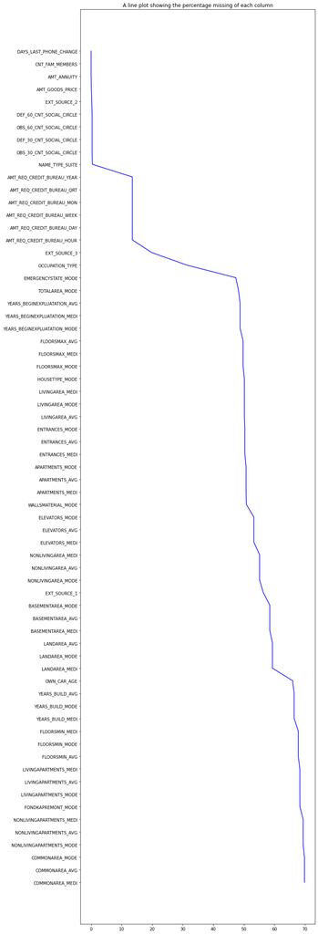

```python
def missing(df,n):
  new_df = missing_percentage(df).reset_index()
  categorical_ = []
  new_df.columns = ['index','flag']
  final_df = []
  for row in new_df.itertuples():
    try:
      final_df.append([row.index,row.flag,df[row.index].median(),df[row.index].mean(), df[row.index].nunique()])
    except:
      final_df.append([row.index,row.flag,df[row.index].mode(),'NA',df[row.index].nunique()])
  columns = ['col_name','percentage_missing','median/Mode','mean','no_of_unique_values']
  temp = pd.DataFrame(final_df,columns=columns)
  return  temp[temp['percentage_missing']>n]

df_25 = missing(df_train,25)
df_analysis = missing(df_train,0)
plt.figure(figsize=[10,40])
plt.plot(df_analysis['percentage_missing'],df_analysis['col_name'] ,color = 'b')
plt.title('A line plot showing the percentage missing of each column')
df_25
```

```python
df_zero = pd.DataFrame()
columns = []
percentage =[]
for col in df_train.columns:
    if col == 'TARGET':
        continue
    count = (df_train[col] == 0).sum()
    columns.append(col)
    percentage.append(count/len(df_train[col]))
df_zero['Column'] = columns
df_zero['Percentage'] = percentage
per = 85/100
df_zero = df_zero[df_zero['Percentage']>per]
```

```python
more_than_85 = df_zero
more_than_85
```

|  | Column | Percentage |
| --- | --- | --- |
| 26 | FLAG_EMAIL | 0.943280 |
| 33 | REG_REGION_NOT_LIVE_REGION | 0.984856 |
| 34 | REG_REGION_NOT_WORK_REGION | 0.949231 |
| 35 | LIVE_REGION_NOT_WORK_REGION | 0.959341 |
| 36 | REG_CITY_NOT_LIVE_CITY | 0.921827 |
| 91 | DEF_30_CNT_SOCIAL_CIRCLE | 0.882323 |
| 93 | DEF_60_CNT_SOCIAL_CIRCLE | 0.912881 |
| 95 | FLAG_DOCUMENT_2 | 0.999958 |
| 97 | FLAG_DOCUMENT_4 | 0.999919 |
| 98 | FLAG_DOCUMENT_5 | 0.984885 |
| 99 | FLAG_DOCUMENT_6 | 0.911945 |
| 100 | FLAG_DOCUMENT_7 | 0.999808 |
| 101 | FLAG_DOCUMENT_8 | 0.918624 |
| 102 | FLAG_DOCUMENT_9 | 0.996104 |
| 103 | FLAG_DOCUMENT_10 | 0.999977 |
| 104 | FLAG_DOCUMENT_11 | 0.996088 |
| 105 | FLAG_DOCUMENT_12 | 0.999993 |
| 106 | FLAG_DOCUMENT_13 | 0.996475 |
| 107 | FLAG_DOCUMENT_14 | 0.997064 |
| 108 | FLAG_DOCUMENT_15 | 0.998790 |
| 109 | FLAG_DOCUMENT_16 | 0.990072 |
| 110 | FLAG_DOCUMENT_17 | 0.999733 |
| 111 | FLAG_DOCUMENT_18 | 0.991870 |
| 112 | FLAG_DOCUMENT_19 | 0.999405 |
| 113 | FLAG_DOCUMENT_20 | 0.999493 |
| 114 | FLAG_DOCUMENT_21 | 0.999665 |
| 115 | AMT_REQ_CREDIT_BUREAU_HOUR | 0.859696 |
| 116 | AMT_REQ_CREDIT_BUREAU_DAY | 0.860142 |

```python
df_train.drop(columns = more_than_85['Column'],inplace = True)
```

```python
df_train =df_train[df_train['NAME_FAMILY_STATUS']!='Unknown']
df_train =df_train[df_train['CODE_GENDER']!='XNA']
df_train =df_train[df_train['NAME_INCOME_TYPE']!='Maternity leave']
```

Saving all the training data targets in the numerical dataframe:

```python
df_numerical= df_train.select_dtypes(exclude='object')
df_numerical['TARGET'] = df_train['TARGET']
df_categorical= df_train.select_dtypes(include='object')
```

```python
df_numerical.describe()
```

|  | SK_ID_CURR | TARGET | CNT_CHILDREN | AMT_INCOME_TOTAL | AMT_CREDIT | AMT_ANNUITY | AMT_GOODS_PRICE | REGION_POPULATION_RELATIVE | DAYS_BIRTH | DAYS_EMPLOYED | ... | NONLIVINGAREA_MEDI | TOTALAREA_MODE | OBS_30_CNT_SOCIAL_CIRCLE | OBS_60_CNT_SOCIAL_CIRCLE | DAYS_LAST_PHONE_CHANGE | FLAG_DOCUMENT_3 | AMT_REQ_CREDIT_BUREAU_WEEK | AMT_REQ_CREDIT_BUREAU_MON | AMT_REQ_CREDIT_BUREAU_QRT | AMT_REQ_CREDIT_BUREAU_YEAR |
| --- | --- | --- | --- | --- | --- | --- | --- | --- | --- | --- | --- | --- | --- | --- | --- | --- | --- | --- | --- | --- | --- |
| count | 307500.000000 | 307500.000000 | 307500.000000 | 3.075000e+05 | 3.075000e+05 | 307488.000000 | 3.072240e+05 | 307500.000000 | 307500.000000 | 307500.000000 | ... | 137824.000000 | 159074.000000 | 306479.000000 | 306479.000000 | 307499.000000 | 307500.000000 | 265986.000000 | 265986.000000 | 265986.000000 | 265986.000000 |
| mean | 278181.087798 | 0.080725 | 0.417034 | 1.687971e+05 | 5.990259e+05 | 27108.477604 | 5.383943e+05 | 0.020868 | -16037.069246 | 63817.429333 | ... | 0.028237 | 0.102548 | 1.422202 | 1.405248 | -962.865681 | 0.710049 | 0.034363 | 0.267390 | 0.265476 | 1.899961 |
| std | 102789.822017 | 0.272413 | 0.722108 | 2.371263e+05 | 4.024936e+05 | 14493.600189 | 3.694459e+05 | 0.013831 | 4363.988872 | 141277.730537 | ... | 0.070168 | 0.107464 | 2.400947 | 2.379760 | 826.813694 | 0.453740 | 0.204687 | 0.915997 | 0.794062 | 1.869288 |
| min | 100002.000000 | 0.000000 | 0.000000 | 2.565000e+04 | 4.500000e+04 | 1615.500000 | 4.050000e+04 | 0.000290 | -25229.000000 | -17912.000000 | ... | 0.000000 | 0.000000 | 0.000000 | 0.000000 | -4292.000000 | 0.000000 | 0.000000 | 0.000000 | 0.000000 | 0.000000 |
| 25% | 189146.750000 | 0.000000 | 0.000000 | 1.125000e+05 | 2.700000e+05 | 16524.000000 | 2.385000e+05 | 0.010006 | -19682.000000 | -2760.000000 | ... | 0.000000 | 0.041200 | 0.000000 | 0.000000 | -1570.000000 | 0.000000 | 0.000000 | 0.000000 | 0.000000 | 0.000000 |
| 50% | 278202.500000 | 0.000000 | 0.000000 | 1.471500e+05 | 5.135310e+05 | 24903.000000 | 4.500000e+05 | 0.018850 | -15750.000000 | -1213.000000 | ... | 0.003100 | 0.068800 | 0.000000 | 0.000000 | -757.000000 | 1.000000 | 0.000000 | 0.000000 | 0.000000 | 1.000000 |
| 75% | 367143.250000 | 0.000000 | 1.000000 | 2.025000e+05 | 8.086500e+05 | 34596.000000 | 6.795000e+05 | 0.028663 | -12413.000000 | -289.000000 | ... | 0.026600 | 0.127600 | 2.000000 | 2.000000 | -274.000000 | 1.000000 | 0.000000 | 0.000000 | 0.000000 | 3.000000 |
| max | 456255.000000 | 1.000000 | 19.000000 | 1.170000e+08 | 4.050000e+06 | 258025.500000 | 4.050000e+06 | 0.072508 | -7489.000000 | 365243.000000 | ... | 1.000000 | 1.000000 | 348.000000 | 344.000000 | 0.000000 | 1.000000 | 8.000000 | 27.000000 | 261.000000 | 25.000000 |

8 rows × 78 columns

```python
df_categorical.describe()
```

|  | NAME_CONTRACT_TYPE | CODE_GENDER | FLAG_OWN_CAR | FLAG_OWN_REALTY | NAME_TYPE_SUITE | NAME_INCOME_TYPE | NAME_EDUCATION_TYPE | NAME_FAMILY_STATUS | NAME_HOUSING_TYPE | OCCUPATION_TYPE | WEEKDAY_APPR_PROCESS_START | ORGANIZATION_TYPE | FONDKAPREMONT_MODE | HOUSETYPE_MODE | WALLSMATERIAL_MODE | EMERGENCYSTATE_MODE |
| --- | --- | --- | --- | --- | --- | --- | --- | --- | --- | --- | --- | --- | --- | --- | --- | --- |
| count | 307500 | 307500 | 307500 | 307500 | 306210 | 307500 | 307500 | 307500 | 307500 | 211112 | 307500 | 307500 | 97211 | 153208 | 151164 | 161750 |
| unique | 2 | 2 | 2 | 2 | 7 | 7 | 5 | 5 | 6 | 18 | 7 | 58 | 4 | 3 | 7 | 2 |
| top | Cash loans | F | N | Y | Unaccompanied | Working | Secondary / secondary special | Married | House / apartment | Laborers | TUESDAY | Business Entity Type 3 | reg oper account | block of flats | Panel | No |
| freq | 278230 | 202443 | 202916 | 213302 | 248520 | 158771 | 218387 | 196424 | 272859 | 55185 | 53898 | 67992 | 73827 | 150497 | 66037 | 159422 |

Checking co-relations of each numerical data which is greater than 3% for both positive and negative co-relation:

```python
correlation = df_numerical.corr()['TARGET'].sort_values(ascending = False).reset_index()
correlation.columns = ['col_name','Correlation']
after_correlation = correlation[abs(correlation['Correlation'])>0.03]

after_correlation
```

|  | col_name | Correlation |
| --- | --- | --- |
| 0 | TARGET | 1.000000 |
| 1 | DAYS_BIRTH | 0.078236 |
| 2 | REGION_RATING_CLIENT_W_CITY | 0.060875 |
| 3 | REGION_RATING_CLIENT | 0.058882 |
| 4 | DAYS_LAST_PHONE_CHANGE | 0.055228 |
| 5 | DAYS_ID_PUBLISH | 0.051455 |
| 6 | REG_CITY_NOT_WORK_CITY | 0.050981 |
| 7 | FLAG_EMP_PHONE | 0.045978 |
| 8 | FLAG_DOCUMENT_3 | 0.044371 |
| 9 | DAYS_REGISTRATION | 0.041950 |
| 10 | OWN_CAR_AGE | 0.037625 |
| 11 | LIVE_CITY_NOT_WORK_CITY | 0.032500 |
| 58 | AMT_CREDIT | -0.030390 |
| 59 | LIVINGAREA_MODE | -0.030688 |
| 60 | ELEVATORS_MODE | -0.032132 |
| 61 | TOTALAREA_MODE | -0.032600 |
| 62 | FLOORSMIN_MODE | -0.032700 |
| 63 | LIVINGAREA_MEDI | -0.032743 |
| 64 | LIVINGAREA_AVG | -0.033001 |
| 65 | FLOORSMIN_MEDI | -0.033397 |
| 66 | FLOORSMIN_AVG | -0.033616 |
| 67 | ELEVATORS_MEDI | -0.033864 |
| 68 | ELEVATORS_AVG | -0.034200 |
| 69 | REGION_POPULATION_RELATIVE | -0.037223 |
| 70 | AMT_GOODS_PRICE | -0.039671 |
| 71 | FLOORSMAX_MODE | -0.043228 |
| 72 | FLOORSMAX_MEDI | -0.043770 |
| 73 | FLOORSMAX_AVG | -0.044005 |
| 74 | DAYS_EMPLOYED | -0.044927 |
| 75 | EXT_SOURCE_1 | -0.155333 |
| 76 | EXT_SOURCE_2 | -0.160451 |
| 77 | EXT_SOURCE_3 | -0.178926 |

```python
df_temp = missing(df_categorical,0)
df_temp
```

|  | col_name | percentage_missing | median/Mode | mean | no_of_unique_values |
| --- | --- | --- | --- | --- | --- |
| 0 | FONDKAPREMONT_MODE | 68.386667 | 0 reg oper account dtype: object | NA | 4 |
| 1 | WALLSMATERIAL_MODE | 50.840976 | 0 Panel dtype: object | NA | 7 |
| 2 | HOUSETYPE_MODE | 50.176260 | 0 block of flats dtype: object | NA | 3 |
| 3 | EMERGENCYSTATE_MODE | 47.398374 | 0 No dtype: object | NA | 2 |
| 4 | OCCUPATION_TYPE | 31.345691 | 0 Laborers dtype: object | NA | 18 |
| 5 | NAME_TYPE_SUITE | 0.419512 | 0 Unaccompanied dtype: object | NA | 7 |

```python
column_remove = ['FONDKAPREMONT_MODE','WALLSMATERIAL_MODE','HOUSETYPE_MODE','EMERGENCYSTATE_MODE','OCCUPATION_TYPE']
df_categorical.drop(columns = column_remove,inplace=True)
```

## Visual Exploratory Data Analysis

In order to obtain a deeper understanding of the data, EDA involves generating summary statistics based on numerical data and creating various graphical representations in order to better understand the data. Data Visualization represents the text or numerical data in a visual format, which makes it easy to grasp the information the data express. We, humans, remember the pictures more easily than readable text, so Python provides us various libraries for data visualization like matplotlib, seaborn, plotly, etc. In this tutorial, we will use Matplotlib and seaborn for performing various techniques to explore data using various plots.

### Visual EDA on numerical data

Numerical data refers to the data that is in the form of numbers, and not in any language or descriptive form.

- **Alias:** Also known as quantitative data as it represents quantitative values to perform arithmetic operations on them.
- **Type:** Discrete data and Continuous data.
- **Analysis:** Descriptive and inferential statistics.
- **Uses:** Used for statistical calculations as a result of the potential performance of arithmetic operations.
- **Structures:** It is structured data and can be quickly organized and made sense of.

```python
df_numerical.info()
```

```
<class 'pandas.core.frame.DataFrame'>
Int64Index: 307500 entries, 0 to 307510
Data columns (total 78 columns):
 #   Column                        Non-Null Count   Dtype
---  ------                        --------------   -----
 0   SK_ID_CURR                    307500 non-null  int64
 1   TARGET                        307500 non-null  int64
 2   CNT_CHILDREN                  307500 non-null  int64
 3   AMT_INCOME_TOTAL              307500 non-null  float64
 4   AMT_CREDIT                    307500 non-null  float64
 5   AMT_ANNUITY                   307488 non-null  float64
 6   AMT_GOODS_PRICE               307224 non-null  float64
 7   REGION_POPULATION_RELATIVE    307500 non-null  float64
 8   DAYS_BIRTH                    307500 non-null  int64
 9   DAYS_EMPLOYED                 307500 non-null  int64
```

[output cut: 70 more lines]

**Here we are plotting graphs of some columns which are positively correlated with target variable and analayzing the trends**

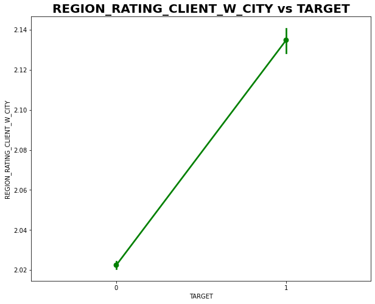

```python
plt.figure(figsize=[10,8])
sb.pointplot(x='TARGET',y='REGION_RATING_CLIENT_W_CITY',data=df_numerical,color= 'GREEN')
plt.title("REGION_RATING_CLIENT_W_CITY vs TARGET", fontweight = 'bold', fontsize = 20)
```

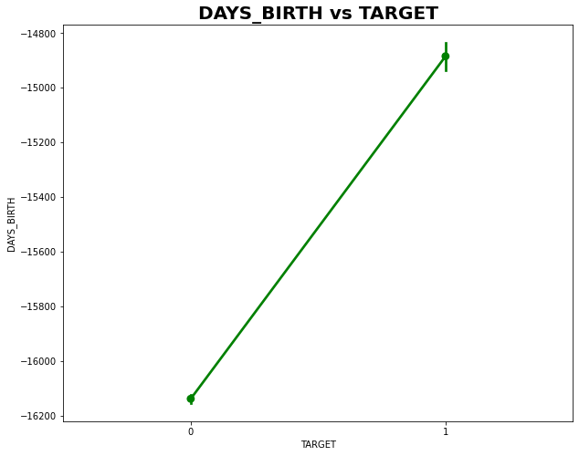

```python
plt.figure(figsize=[10,8])
sb.pointplot(x='TARGET',y='DAYS_BIRTH',data=df_numerical,color= 'GREEN')
plt.title("DAYS_BIRTH vs TARGET", fontweight = 'bold', fontsize = 20)
```

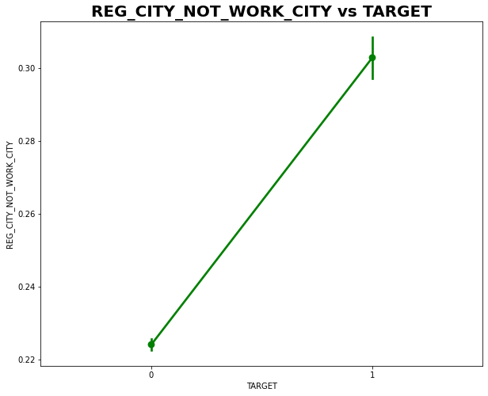

```python
plt.figure(figsize=[10,8])
sb.pointplot(x='TARGET',y='REG_CITY_NOT_WORK_CITY',data=df_numerical,color= 'GREEN')
plt.title("REG_CITY_NOT_WORK_CITY vs TARGET", fontweight = 'bold', fontsize = 20)
```

**Here we are plotting graphs of some columns which are negatively correlated with target variable and analayzing the trends**

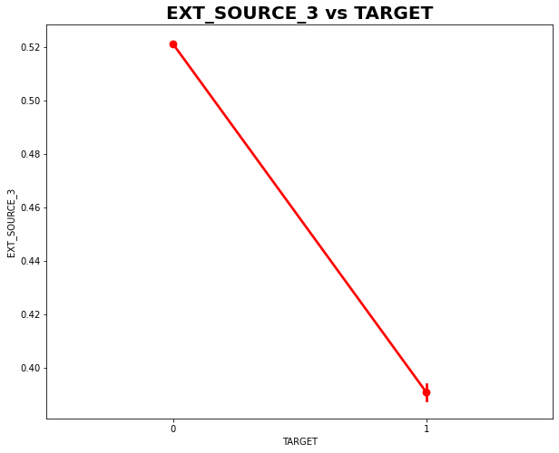

```python
plt.figure(figsize=[10,8])
sb.pointplot(x='TARGET',y='EXT_SOURCE_3',data=df_numerical,color= 'RED')
plt.title("EXT_SOURCE_3 vs TARGET", fontweight = 'bold', fontsize = 20)
```

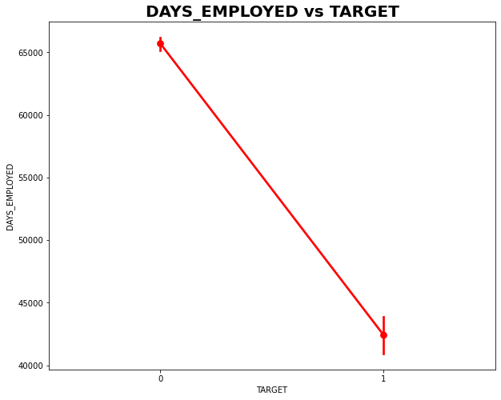

```python
plt.figure(figsize=[10,8])
sb.pointplot(x='TARGET',y='DAYS_EMPLOYED',data=df_numerical,color= 'RED')
plt.title("DAYS_EMPLOYED vs TARGET", fontweight = 'bold', fontsize = 20)
```

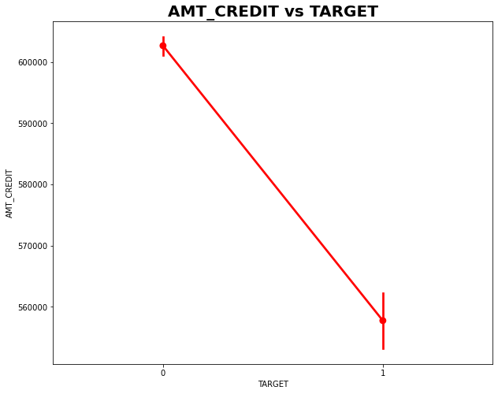

```python
plt.figure(figsize=[10,8])
sb.pointplot(x='TARGET',y='AMT_CREDIT',data=df_numerical,color= 'RED')
plt.title("AMT_CREDIT vs TARGET", fontweight = 'bold', fontsize = 20)
```

**Plotting heatmap to analyze correlatoin in application train dataset**

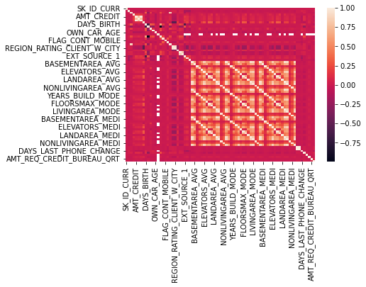

```python
sb.heatmap(df_train.corr());
```

**Plotting heatmap to see correlation in application test dataset**

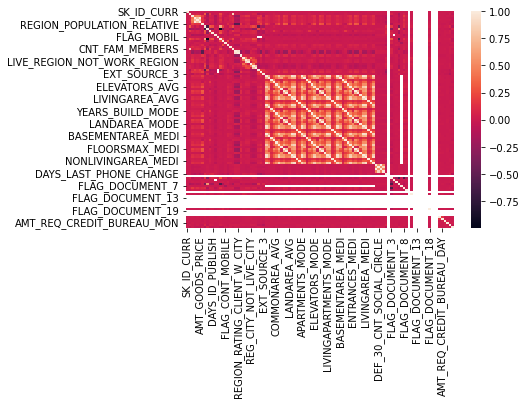

```python
sb.heatmap(df_test.corr());
```

### Visual EDA on categorical data

Categorical data refers to a data type that can be stored and identified based on the names or labels given to them.

- **Alias:** Also known as qualitative data as it qualifies data before classifying it.
- **Type:** Nominal data and Ordinal data.
- **Analysis:** Median and mode.
- **Uses:** Used when a study requires respondents’ personal information, opinions and experiences. Commonly used in business research.
- **Structures:** Is known as unstructured or semi-structured data.

```python
df_categorical.info()
```

```
<class 'pandas.core.frame.DataFrame'>
Int64Index: 307500 entries, 0 to 307510
Data columns (total 11 columns):
 #   Column                      Non-Null Count   Dtype
---  ------                      --------------   -----
 0   NAME_CONTRACT_TYPE          307500 non-null  object
 1   CODE_GENDER                 307500 non-null  object
 2   FLAG_OWN_CAR                307500 non-null  object
 3   FLAG_OWN_REALTY             307500 non-null  object
 4   NAME_TYPE_SUITE             306210 non-null  object
 5   NAME_INCOME_TYPE            307500 non-null  object
 6   NAME_EDUCATION_TYPE         307500 non-null  object
 7   NAME_FAMILY_STATUS          307500 non-null  object
 8   NAME_HOUSING_TYPE           307500 non-null  object
 9   WEEKDAY_APPR_PROCESS_START  307500 non-null  object
 10  ORGANIZATION_TYPE           307500 non-null  object
dtypes: object(11)
memory usage: 36.2+ MB
```

```
Y    213302
N     94198
Name: FLAG_OWN_REALTY, dtype: int64
```

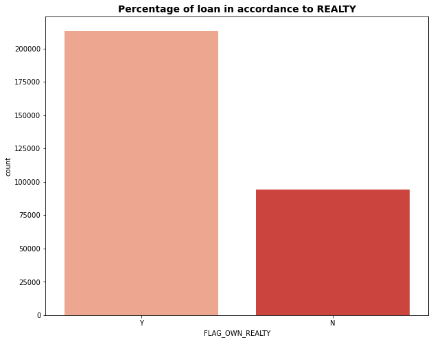

```python
eda_cat1 = df_categorical['FLAG_OWN_REALTY'].value_counts()
print(eda_cat1)

plt.figure(figsize=[10,8])
sb.countplot(df_categorical['FLAG_OWN_REALTY'],palette = 'Reds')
plt.title("Percentage of loan in accordance to REALTY", fontweight = 'bold', fontsize = 14)
```

**From this graph we can figure out that if a person owns a realty or not**

```
Working                 158771
Commercial associate     71614
Pensioner                55362
State servant            21703
Unemployed                  22
Student                     18
Businessman                 10
Name: NAME_INCOME_TYPE, dtype: int64
```

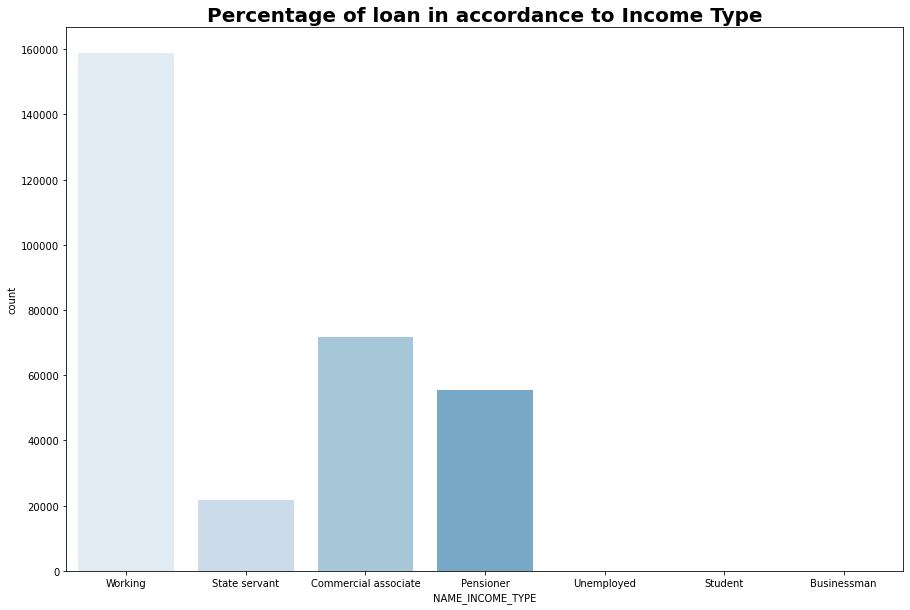

```python
eda_cat2 = df_categorical['NAME_INCOME_TYPE'].value_counts()
print(eda_cat2)

plt.figure(figsize=[15,10])
sb.countplot(df_categorical['NAME_INCOME_TYPE'],palette = 'Blues')
plt.title("Percentage of loan in accordance to Income Type", fontweight = 'bold', fontsize = 20)
```

**From the above graph we can see that the most borrowing category are the people who are from the working class**

```
Cash loans         278230
Revolving loans     29270
Name: NAME_CONTRACT_TYPE, dtype: int64
```

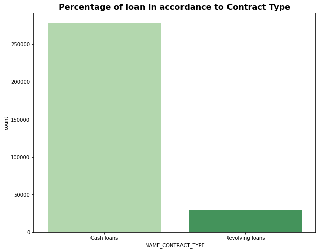

```python
eda_cat3 = df_categorical['NAME_CONTRACT_TYPE'].value_counts()
print(eda_cat3)

plt.figure(figsize=[10,8])
sb.countplot(df_categorical['NAME_CONTRACT_TYPE'],palette = 'Greens')
plt.title("Percentage of loan in accordance to Contract Type", fontweight = 'bold', fontsize = 16)
```

**From the above graph we can see the type of loan people take**

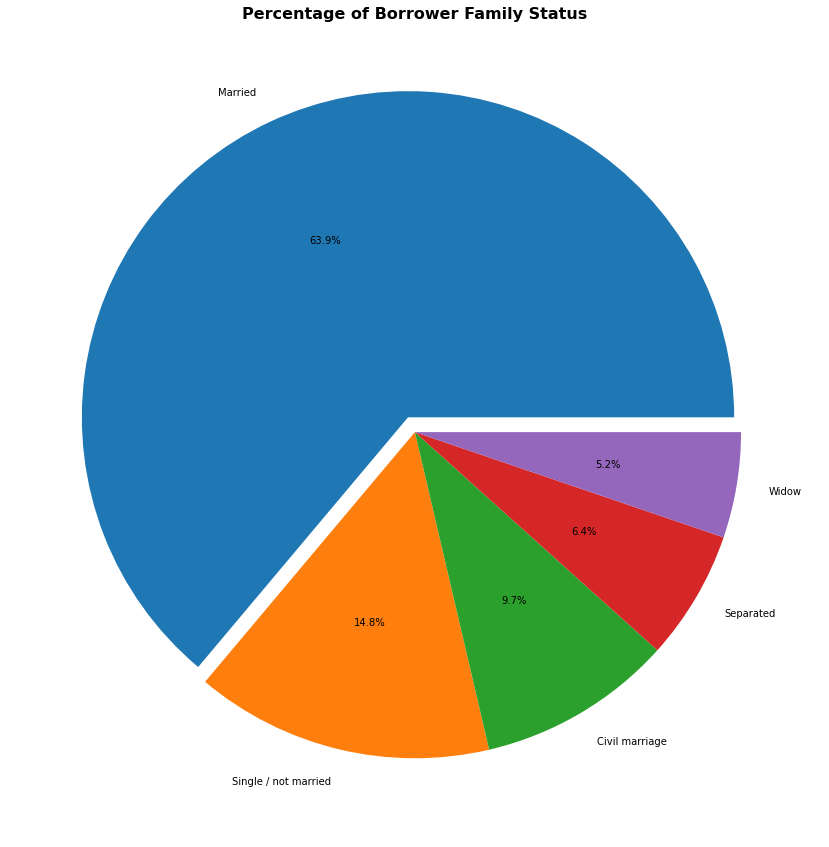

```python
plt.figure(figsize=[20,15])
plt.pie(df_categorical['NAME_FAMILY_STATUS'].value_counts(),explode = (0.05,0,0,0,0) ,labels = df_categorical['NAME_FAMILY_STATUS'].value_counts().index,autopct='%1.1f%%')
#p=plt.gcf()
plt.title('Percentage of Borrower Family Status', fontweight = 'bold', fontsize = 16)
plt.show()
```

**From the above pie chart we can that Married people tend borrow more money**

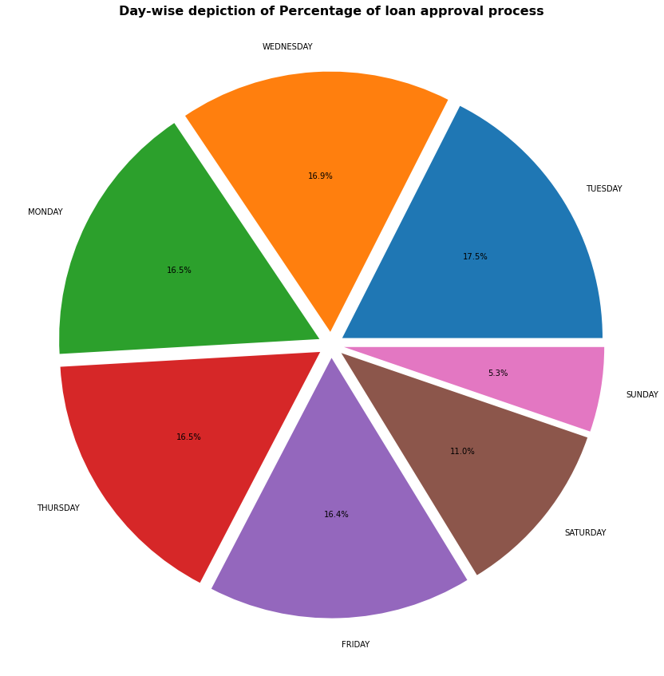

```python
plt.figure(figsize=[20,15])
plt.pie(df_categorical['WEEKDAY_APPR_PROCESS_START'].value_counts(),explode = (0.05,0.05,0.05,0.05,0.05,0.05,0.05),labels = df_categorical['WEEKDAY_APPR_PROCESS_START'].value_counts().index,autopct='%1.1f%%')
#p=plt.gcf()
plt.title('Day-wise depiction of Percentage of loan approval process', fontweight = 'bold', fontsize = 16)
plt.show()
```

## Modeling Pipelines

Now comes the fun part. Models are general rules in a statistical sense.Think of a machine learning model as tools in your toolbox. You will have access to many algorithms and use them to accomplish different goals. The better features you use the better your predictive power will be. After cleaning your data and finding what features are most important, using your model as a predictive tool will only enhance your model decision making.

Collectively, the linear sequence of steps required to prepare the data, tune the model, and transform the predictions is called the modeling pipeline. Modern machine learning libraries like the scikit-learn Python library allow this sequence of steps to be defined and used correctly (without data leakage) and consistently (during evaluation and prediction). A pipeline is a linear sequence of data preparation options, modeling operations, and prediction transform operations.

The modeling pipeline is an important tool for machine learning practitioners. Nevertheless, there are important implications that must be considered when using them. The main confusion for beginners when using pipelines comes in understanding what the pipeline has learned or the specific configuration discovered by the pipeline.

Therefore, for this project we are going to use 3 different modeling pipeline methods to perform home credit default risk prediction and they are:

- Naive Bayes
- Logistic Regression
- Random Forest

We will choose the model that gives the best accuracy for the home credit default risk prediction.

We will be using the following pipeline for this project:

[figure not shown]

Importing all the necessary python libraries for the different pipelines we are going to use:

```python
from sklearn.pipeline import Pipeline
from sklearn.impute import SimpleImputer
from sklearn.naive_bayes import GaussianNB
from sklearn.preprocessing import OneHotEncoder
from sklearn.preprocessing import StandardScaler
from sklearn.linear_model import LogisticRegression
from sklearn.ensemble import RandomForestClassifier
from sklearn.model_selection import train_test_split
from sklearn.compose import ColumnTransformer, make_column_transformer
```

```python
df_numerical.drop(columns = ['TARGET'],inplace=True)
df_cols = list(df_numerical.columns)+ list(df_categorical.columns)
df_i = df_train[df_cols]
```

Here for pipeline for numerical data(numerical_pipeline) we are imputing the missing values by mean of the column and for pipeline for categorical data(categorical_pipeline) we are imputing missing values by most frequent data and implementing one hot encoding for categorical pipeline to deal with categorical data.

Then we have created a pipeline to merge numerical and categorical pipelines using ColumnTransformer.

```python
numerical_pipeline = Pipeline([('imputer', SimpleImputer(strategy='mean'))])

categorical_pipeline = Pipeline([
        ('imputer', SimpleImputer(strategy='most_frequent')),
        ('ohe', OneHotEncoder(sparse=False, handle_unknown="ignore"))])
```

```python
data_pipeline = ColumnTransformer([
    ("num_pipeline", numerical_pipeline, df_numerical.columns),
    ("cat_pipeline", categorical_pipeline, df_categorical.columns)], n_jobs = -1)
df_transformed = data_pipeline.fit_transform(df_i)
final_column_names = list(df_numerical.columns)  + \
               list(data_pipeline.transformers_[1][1].named_steps["ohe"].get_feature_names(df_categorical.columns))
```

```python
df_final = pd.DataFrame(df_transformed,  columns=final_column_names)
```

```python
X = df_final.values
y = df_train['TARGET'].values
```

Splitting the dataset for training and testing:

```python
X_train, X_valid, y_train, y_valid = train_test_split(X, y, test_size=0.25, random_state=123)
```

### Naive Bayes

Library: https://scikit-learn.org/stable/modules/generated/sklearn.naive_bayes.GaussianNB.html

Naive Bayes is a basic but effective probabilistic classification model in machine learning that draws influence from Bayes Theorem.

Bayes theorem is a formula that offers a conditional probability of an event A taking happening given another event B has previously happened. Its mathematical formula is as follows: –

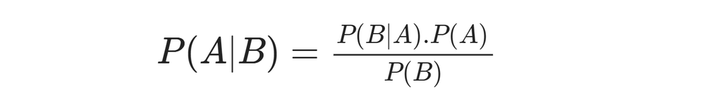

Where

A and B are two events P(A|B) is the probability of event A provided event B has already happened. P(B|A) is the probability of event B provided event A has already happened. P(A) is the independent probability of A P(B) is the independent probability of B Now, this Bayes theorem can be used to generate the following classification model –

[figure not shown]

Where

X = x1,x2,x3,.. xN аre list оf indeрendent рrediсtоrs y is the class label P(y|X) is the probability of label y given the predictors X The above equation may be extended as follows:

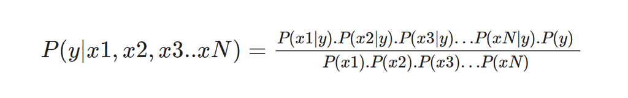

```python
pipe_naive_bayes = Pipeline([
('scaler', StandardScaler()),
('classifier', GaussianNB())])

pipe_naive_bayes.fit(X_train, y_train)
```

```
Pipeline(steps=[('scaler', StandardScaler()), ('classifier', GaussianNB())])
```

### Logistic Regression

Library: https://scikit-learn.org/stable/modules/generated/sklearn.linear_model.LogisticRegression.html

Logistic regression is a statistical method for predicting binary classes. The outcome or target variable is dichotomous in nature. Dichotomous means there are only two possible classes. For example, it can be used for cancer detection problems. It computes the probability of an event occurrence.

It is a special case of linear regression where the target variable is categorical in nature. It uses a log of odds as the dependent variable. Logistic Regression predicts the probability of occurrence of a binary event utilizing a logit function.

Properties of Logistic Regression:

The dependent variable in logistic regression follows Bernoulli Distribution. Estimation is done through maximum likelihood. No R Square, Model fitness is calculated through Concordance, KS-Statistics.

```python
pipe = Pipeline([
('scaler', StandardScaler()),
('classifier', LogisticRegression(solver='newton-cg', max_iter=2500))])

pipe.fit(X_train, y_train)
```

```
Pipeline(steps=[('scaler', StandardScaler()),
                ('classifier',
                 LogisticRegression(max_iter=2500, solver='newton-cg'))])
```

### Random Forest

Library: https://scikit-learn.org/stable/modules/generated/sklearn.ensemble.RandomForestClassifier.html

Random forest is a Supervised Machine Learning Algorithm that is used widely in Classification and Regression problems. It builds decision trees on different samples and takes their majority vote for classification and average in case of regression.

Random forest works on the Bagging principle. Bagging, also known as Bootstrap Aggregation is the ensemble technique used by random forest. Bagging chooses a random sample from the data set. Hence each model is generated from the samples (Bootstrap Samples) provided by the Original Data with replacement known as row sampling. This step of row sampling with replacement is called bootstrap. Now each model is trained independently which generates results. The final output is based on majority voting after combining the results of all models. This step which involves combining all the results and generating output based on majority voting is known as aggregation.

Steps involved in random forest algorithm:

- Step 1: In Random forest n number of random records are taken from the data set having k number of records.
- Step 2: Individual decision trees are constructed for each sample.
- Step 3: Each decision tree will generate an output.
- Step 4: Final output is considered based on Majority Voting or Averaging for Classification and regression respectively.

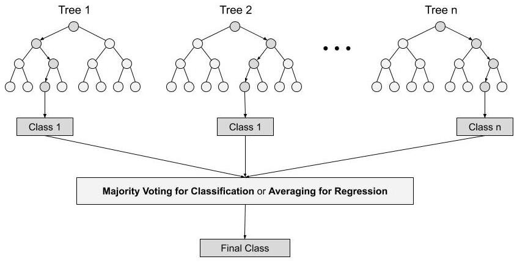

```python
pipe_rf = Pipeline([
('scaler', StandardScaler()),
('classifier', RandomForestClassifier())])

pipe_rf.fit(X_train, y_train)
```

```
Pipeline(steps=[('scaler', StandardScaler()),
                ('classifier', RandomForestClassifier())])
```

## Results and Discussion of Results

In our industry, we consider different kinds of metrics to evaluate our models. The choice of metric completely depends on the type of model and the implementation plan of the model. After finishing the building of the model, multiple metrics can be used to help in evaluating your model’s accuracy.

### Metrics

For this project, we are going to use the following performance metrics for each of the training models seperately:

- **Accuracy:** Classification Accuracy is what we usually mean, when we use the term accuracy. It is the ratio of number of correct predictions to the total number of input samples. It works well only if there are equal number of samples belonging to each class.

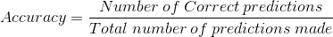

- **Log Loss:** Logarithmic Loss or Log Loss, works by penalising the false classifications. It works well for multi-class classification. When working with Log Loss, the classifier must assign probability to each class for all the samples. Suppose, there are N samples belonging to M classes, then the Log Loss is calculated as below :

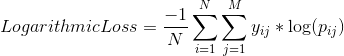

where, y_ij, indicates whether sample i belongs to class j or not p_ij, indicates the probability of sample i belonging to class j

Importing all the necessary metrics libraries:

```python
from sklearn.metrics import log_loss
from sklearn.metrics import accuracy_score
from sklearn.metrics import confusion_matrix
from sklearn.metrics import roc_auc_score
from sklearn.metrics import f1_score
import matplotlib.pyplot as plt
from sklearn import metrics

model_compare = []
```

### Model Results

#### Naive Bayes

```python
print('Training accuracy: ' + str(pipe_naive_bayes.score(X_train,y_train)))
y_pred = pipe_naive_bayes.predict(X_valid)
print('Test accuracy: ' + str(accuracy_score(y_valid,y_pred)))
print('Log loss: ',log_loss(y_valid,y_pred))
print('F1 Score: ',f1_score(y_valid,y_pred,average = 'weighted'))
print('Confusion Matrix: ','\n',confusion_matrix(y_valid, y_pred))
print('ROC_AUC: ',roc_auc_score(y_valid, pipe_naive_bayes.predict_proba(X_valid)[:, 1]))
```

```
Training accuracy: 0.1682081300813008
Test accuracy: 0.16507317073170732
Log loss:  28.838014527851993
F1 Score:  0.1746395400294703
Confusion Matrix:
 [[ 6879 63787]
 [  398  5811]]
ROC_AUC:  0.6046727956730314
```

```
<sklearn.metrics._plot.roc_curve.RocCurveDisplay at 0xffff36036850>
```

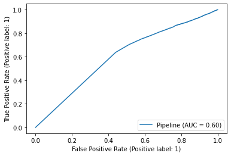

```python
model_compare.append(['Naive Bayes',pipe_naive_bayes.score(X_train,y_train),accuracy_score(y_valid,y_pred)])
metrics.plot_roc_curve(pipe_naive_bayes, X_valid, y_valid)
```

#### Logistic Regression

```python
print('Training accuracy: ' + str(pipe.score(X_train,y_train)))
y_pred = pipe.predict(X_valid)
print('Test accuracy: ' + str(accuracy_score(y_valid,y_pred)))
print('Log loss: ',log_loss(y_valid,y_pred))
print('F1 Score: ',f1_score(y_valid,y_pred,average = 'weighted'))
print('Confusion Matrix: ','\n',confusion_matrix(y_valid, y_pred))
print('ROC_AUC: ',roc_auc_score(y_valid, pipe.predict_proba(X_valid)[:, 1]))
```

```
Training accuracy: 0.919180487804878
Test accuracy: 0.9193365853658536
Log loss:  2.786016254973523
F1 Score:  0.8822734992788148
Confusion Matrix:
 [[70607    59]
 [ 6142    67]]
ROC_AUC:  0.7442088694938733
```

```
<sklearn.metrics._plot.roc_curve.RocCurveDisplay at 0xffff56f2f8b0>
```

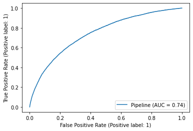

```python
model_compare.append(['Logistic Regression',pipe.score(X_train,y_train),accuracy_score(y_valid,y_pred)])
metrics.plot_roc_curve(pipe, X_valid, y_valid)
```

#### Random Forest

```python
print('Training accuracy: ' + str(pipe_rf.score(X_train,y_train)))
y_pred = pipe_rf.predict(X_valid)
print('Test accuracy: ' + str(accuracy_score(y_valid,y_pred)))
print('Log loss: ',log_loss(y_valid,y_pred))
print('F1 Score: ',f1_score(y_valid,y_pred,average = 'weighted'))
print('Confusion Matrix: ','\n',confusion_matrix(y_valid, y_pred))
print('ROC_AUC: ',roc_auc_score(y_valid, pipe_rf.predict_proba(X_valid)[:, 1]))
```

```
Training accuracy: 0.9999653116531165
Test accuracy: 0.9193626016260162
Log loss:  2.7851170923088935
F1 Score:  0.8809183893558904
Confusion Matrix:
 [[70664     2]
 [ 6197    12]]
ROC_AUC:  0.7134118767406149
```

```
<sklearn.metrics._plot.roc_curve.RocCurveDisplay at 0xffff56e9d280>
```

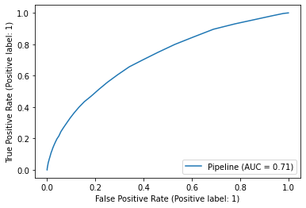

```python
model_compare.append(['Random Forest Classifier',pipe_rf.score(X_train,y_train),accuracy_score(y_valid,y_pred)])
metrics.plot_roc_curve(pipe_rf, X_valid, y_valid)
```

### Compiled results

```python
pd.DataFrame(model_compare,columns = ['Model Name', 'Training Accuracy', 'Test Accuracy'])
```

|  | Model Name | Training Accuracy | Test Accuracy |
| --- | --- | --- | --- |
| 0 | Naive Bayes | 0.168208 | 0.165073 |
| 1 | Logistic Regression | 0.919180 | 0.919337 |
| 2 | Random Forest Classifier | 0.999965 | 0.919363 |

## Kaggle Submission

Machine learning competitions are a great way to improve your skills and measure your progress as a data scientist. If you are using data from a competition on Kaggle, you can easily submit it from your notebook. We make submissions in CSV files. Your submissions usually have two columns: an ID column and a prediction column. The ID field comes from the test data (keeping whatever name the ID field had in that data, which for the housing data is the string 'Id'). The prediction column will use the name of the target field.

```python
df_test_final = df_test[df_cols]
df_test_final
```

|  | SK_ID_CURR | CNT_CHILDREN | AMT_INCOME_TOTAL | AMT_CREDIT | AMT_ANNUITY | AMT_GOODS_PRICE | REGION_POPULATION_RELATIVE | DAYS_BIRTH | DAYS_EMPLOYED | DAYS_REGISTRATION | ... | CODE_GENDER | FLAG_OWN_CAR | FLAG_OWN_REALTY | NAME_TYPE_SUITE | NAME_INCOME_TYPE | NAME_EDUCATION_TYPE | NAME_FAMILY_STATUS | NAME_HOUSING_TYPE | WEEKDAY_APPR_PROCESS_START | ORGANIZATION_TYPE |
| --- | --- | --- | --- | --- | --- | --- | --- | --- | --- | --- | --- | --- | --- | --- | --- | --- | --- | --- | --- | --- | --- |
| 0 | 100001 | 0 | 135000.0 | 568800.0 | 20560.5 | 450000.0 | 0.018850 | -19241 | -2329 | -5170.0 | ... | F | N | Y | Unaccompanied | Working | Higher education | Married | House / apartment | TUESDAY | Kindergarten |
| 1 | 100005 | 0 | 99000.0 | 222768.0 | 17370.0 | 180000.0 | 0.035792 | -18064 | -4469 | -9118.0 | ... | M | N | Y | Unaccompanied | Working | Secondary / secondary special | Married | House / apartment | FRIDAY | Self-employed |
| 2 | 100013 | 0 | 202500.0 | 663264.0 | 69777.0 | 630000.0 | 0.019101 | -20038 | -4458 | -2175.0 | ... | M | Y | Y | NaN | Working | Higher education | Married | House / apartment | MONDAY | Transport: type 3 |
| 3 | 100028 | 2 | 315000.0 | 1575000.0 | 49018.5 | 1575000.0 | 0.026392 | -13976 | -1866 | -2000.0 | ... | F | N | Y | Unaccompanied | Working | Secondary / secondary special | Married | House / apartment | WEDNESDAY | Business Entity Type 3 |
| 4 | 100038 | 1 | 180000.0 | 625500.0 | 32067.0 | 625500.0 | 0.010032 | -13040 | -2191 | -4000.0 | ... | M | Y | N | Unaccompanied | Working | Secondary / secondary special | Married | House / apartment | FRIDAY | Business Entity Type 3 |
| ... | ... | ... | ... | ... | ... | ... | ... | ... | ... | ... | ... | ... | ... | ... | ... | ... | ... | ... | ... | ... | ... |
| 48739 | 456221 | 0 | 121500.0 | 412560.0 | 17473.5 | 270000.0 | 0.002042 | -19970 | -5169 | -9094.0 | ... | F | N | Y | Unaccompanied | Working | Secondary / secondary special | Widow | House / apartment | WEDNESDAY | Other |
| 48740 | 456222 | 2 | 157500.0 | 622413.0 | 31909.5 | 495000.0 | 0.035792 | -11186 | -1149 | -3015.0 | ... | F | N | N | Unaccompanied | Commercial associate | Secondary / secondary special | Married | House / apartment | MONDAY | Trade: type 7 |
| 48741 | 456223 | 1 | 202500.0 | 315000.0 | 33205.5 | 315000.0 | 0.026392 | -15922 | -3037 | -2681.0 | ... | F | Y | Y | Unaccompanied | Commercial associate | Secondary / secondary special | Married | House / apartment | WEDNESDAY | Business Entity Type 3 |
| 48742 | 456224 | 0 | 225000.0 | 450000.0 | 25128.0 | 450000.0 | 0.018850 | -13968 | -2731 | -1461.0 | ... | M | N | N | Family | Commercial associate | Higher education | Married | House / apartment | MONDAY | Self-employed |
| 48743 | 456250 | 0 | 135000.0 | 312768.0 | 24709.5 | 270000.0 | 0.006629 | -13962 | -633 | -1072.0 | ... | F | Y | N | Unaccompanied | Working | Secondary / secondary special | Married | House / apartment | TUESDAY | Government |

48744 rows × 88 columns

```python
df_transformed = data_pipeline.fit_transform(df_test)
column_names = list(df_numerical.columns)  + \
               list(data_pipeline.transformers_[1][1].named_steps["ohe"].get_feature_names(df_categorical.columns))
```

```python
df_transformed.shape
```

```
(48744, 180)
```

```python
df_final_test = pd.DataFrame(df_transformed,columns=column_names)
X = df_final_test.values
result = pipe_rf.predict(X)
result_prob = pipe_rf.predict_proba(X)
r = pd.DataFrame(result_prob,columns=['class_0_prob','class_1_prob'])
r[['class_0_prob','class_1_prob']] = result_prob
final_sub = pd.DataFrame()
final_sub['SK_ID_CURR'] = df_test['SK_ID_CURR']
final_sub['TARGET'] = r['class_1_prob']
final_sub = final_sub.set_index('SK_ID_CURR')
final_sub
```

| SK_ID_CURR | TARGET |
| --- | --- |
| 100001 | 0.13 |
| 100005 | 0.20 |
| 100013 | 0.10 |
| 100028 | 0.09 |
| 100038 | 0.20 |
| ... | ... |
| 456221 | 0.10 |
| 456222 | 0.17 |
| 456223 | 0.08 |
| 456224 | 0.07 |
| 456250 | 0.19 |

48744 rows × 1 columns

```python
final_sub.to_csv('submission.csv')
```

**The results for our project submission on kaggle is as follows:**

Note: We did not submit the file for Naive Bayes because the accuracy is way too low to begin with.

- **Logistic regression:**

[figure not shown]

- **Random Forest:**

[figure not shown]

## Conclusions

The best model that we could obtain for Phase 1 was Logistic Regression, which has a training accuracy of 91.9% and a Kaggle submission accuracy of 0.73. To improve the model during the next phase, we plan to perform hyperparameter tuning for our models along with using K-Fold cross validation and GridSearchCV. We might even use some advanced gradient boosting models in order to achieve the maximum accuracy.

## References

- Pipeline: https://scikit-learn.org/stable/
- Data: https://www.kaggle.com/c/home-credit-default-risk/data
- Metrics: https://towardsdatascience.com/metrics-to-evaluate-your-machine-learning-algorithm-f10ba6e38234
- Professor's baseline notebook: https://github.iu.edu/jshanah/I526_AML_Student/blob/master/Assignments/Unit-Project-Home-Credit-Default-Risk/HCDR_Phase_1_baseline_submission/HCDR_baseLine_submission_with_numerical_and_cat_features_to_kaggle.ipynb